# hw2

Author

Rao Yuner

```r
#problem1_a  momentum_walk(n,p)
momentum_walk <- function(n, p) {
  if (length(n) != 1 || !is.numeric(n) || n < 0 || n != floor(n)) {
    stop("n must be a non-negative integer")
  }
  if (length(p) != 1 || !is.numeric(p) || p < 0 || p > 1) {
    stop("p must be between 0 and 1")
  }
  directions <- matrix(
    c(1, 0,
      -1, 0,
      0, 1,
      0, -1),
    ncol = 2,
    byrow = TRUE
  )
  position <- c(0, 0)
  current_direction <- sample(1:4, 1)
  position <- position + directions[current_direction, ]
  if (n >= 2) {
    for (i in 2:n) {
      if (runif(1) < p) {
      } else {
        current_direction <- sample(1:4, 1)
      }
      position <- position + directions[current_direction, ]
    }
  }
  return(position)
}

#set example
momentum_walk(10, 0.6)
```

```
[1] -7  1
```

### Explanation problem1(a)

if we run the same parameters for several times, the outputs are different.

```r
#problem1_b
#version1
momentum_walk1 <- function(n, p) {
  if (length(n) != 1 || !is.numeric(n) || n < 0 || n != floor(n)) {
    stop("n must be a non-negative integer")
  }
  if (length(p) != 1 || !is.numeric(p) || p < 0 || p > 1) {
    stop("p must be between 0 and 1")
  }
  directions <- matrix(
    c(1, 0,
      -1, 0,
      0, 1,
      0, -1),
    ncol = 2,
    byrow = TRUE
  )
  position <- c(0, 0)
  current_direction <- sample(1:4, 1)
  position <- position + directions[current_direction, ]
  if (n >= 2) {
    for (i in 2:n) {
      if (runif(1) < p) {
      } else {
        current_direction <- sample(1:4, 1)
      }
      position <- position + directions[current_direction, ]
    }
  }
  return(position)
}
#version 1 test
momentum_walk1(10, 0.6)
```

```
[1] 8 2
```

```r
momentum_walk1(1000, 0.6)
```

```
[1] -75  85
```

```r
#version2
momentum_walk2 <- function(n, p) {
  if (length(n) != 1 || !is.numeric(n) || n < 0 || n != floor(n)) {
    stop("n must be a non-negative integer")
  }
  if (length(p) != 1 || !is.numeric(p) || p < 0 || p > 1) {
    stop("p must be between 0 and 1")
  }
  directions <- matrix(
    c(1, 0,
      -1, 0,
      0, 1,
      0, -1),
    ncol = 2,
    byrow = TRUE
  )
  current_direction <- sample(1:4, 1)
  one_step <- function() {
    if (runif(1) >= p) {
      current_direction <<- sample(1:4, 1)
    }
    directions[current_direction, ]
  }
  position <- directions[current_direction, ]
  if (n >= 2) {
    steps <- replicate(n - 1, one_step())
    position <- position + rowSums(steps)
  }
  return(position)
}
#version2 test
momentum_walk2(10, 0.6)
```

```
[1]  0 10
```

```r
momentum_walk2(1000, 0.6)
```

```
[1]  13 -23
```

### Explanation problem1(b)

### Version 1

Version 1 uses a for loop. At each step, the function either keeps the previous direction with probability p or randomly selects a new direction with probability 1-p. The position is then updated by adding the corresponding direction vector.

### Version 2

Version 2 uses replicate() to repeat the step simulation. The previous direction is stored and updated after each simulated step, so the momentum dependence is preserved.

```r
#problem1_c
#set example
set.seed(123)
momentum_walk1(10, 0.6)
```

```
[1] 1 7
```

```r
set.seed(123)
momentum_walk1(10, 0.6)
```

```
[1] 1 7
```

```r
set.seed(123)
momentum_walk1(1000, 0.6)
```

```
[1] -46  -4
```

```r
set.seed(123)
momentum_walk1(1000, 0.6)
```

```
[1] -46  -4
```

### Explanation problem1(c)

I used set.seed(123) before each simulation. This fixes the starting point of R’s pseudorandom number generator, so the same sequence of random numbers is generated each time.

```r
#problem1_d
set.seed(123)
p_values <- c(0, 0.5, 0.9)
for (p in p_values) {
  position <- momentum_walk1(1000, p)
  distance <- sqrt(sum(position^2))
  cat("p =", p,
      "position =", position,
      "distance =", distance, "\n")
}
```

```
p = 0 position = 4 16 distance = 16.49242
p = 0.5 position = 79 23 distance = 82.28001
p = 0.9 position = -105 5 distance = 105.119
```

### Explanation problem1(d)

Increasing momentum tends to increase the final distance from the origin.The larger momentum, the stronger movement persistence, the fewer cancellations, and bigger distance.

```r
#problem1_e
p_values <- c(0, 0.25, 0.5, 0.75, 0.9)
mean_distance <- sapply(p_values, function(p) {
  distances <- replicate(1000, {
    position <- momentum_walk1(1000, p)
    sqrt(sum(position^2))
  })
  mean(distances)
})
results <- data.frame(
  p = p_values,
  mean_distance = mean_distance
)
print(results)
```

```
     p mean_distance
1 0.00      28.67471
2 0.25      35.41211
3 0.50      47.68052
4 0.75      73.00891
5 0.90     121.11332
```

### Explanation problem1(e)

The mean final distance generally increases as momentum increases. When p is larger, the particle is more likely to continue moving in the same direction, so consecutive steps are more persistent and there is less cancellation between steps.

```r
#problem1_f
library(microbenchmark)
#n=1000
library(microbenchmark)
benchmark_1000 <- microbenchmark(
  loop = momentum_walk1(1000, 0.6),
  replicate = momentum_walk2(1000, 0.6),
  times = 100
)
print(benchmark_1000)
```

```
Unit: microseconds
      expr      min        lq      mean    median        uq      max neval
      loop  877.195  959.8305  995.5054  980.9865  998.9855 1319.052   100
 replicate 1279.692 1334.4270 1386.4761 1359.7035 1385.1645 1817.858   100
```

```r
#n=100000
benchmark_100000 <- microbenchmark(
  loop = momentum_walk1(100000, 0.6),
  replicate = momentum_walk2(100000, 0.6),
  times = 100
)
print(benchmark_100000)
```

```
Unit: milliseconds
      expr     min       lq     mean   median       uq      max neval
      loop  98.182 100.6501 103.9654 102.3869 104.9603 126.4900   100
 replicate 135.708 141.3117 145.9104 143.7290 148.5146 168.8085   100
```

### Explanation problem1(f)

```r
#problem2
set.seed(123)
# Number of simulated days
n_days <- 10000
# 6 AM to 8 AM: 3 hours
morning <- matrix(
  rpois(n_days * 3, lambda = 4),
  nrow = n_days,
  ncol = 3
)
# 9 AM: 1 hour
nine_am <- rnorm(
  n_days,
  mean = 45,
  sd = sqrt(16)
)
# 10 AM to 3 PM: 6 hours
midday <- matrix(
  rpois(n_days * 6, lambda = 15),
  nrow = n_days,
  ncol = 6
)
# 4 PM: 1 hour
four_pm <- rnorm(
  n_days,
  mean = 55,
  sd = sqrt(25)
)
# 5 PM to 10 PM: 6 hours
evening <- matrix(
  rpois(n_days * 6, lambda = 9),
  nrow = n_days,
  ncol = 6
)
# Total passengers for each day
daily_total <- rowSums(morning) +
  nine_am +
  rowSums(midday) +
  four_pm +
  rowSums(evening)
# Monte Carlo estimate of expected daily passengers
mean(daily_total)
```

```
[1] 256.0589
```

### Explanation problem2

I simulated 10,000 days without using loops. For each time period, I generated the appropriate number of random observations using rpois( ) or rnorm( ). For periods containing multiple hours, I stored the observations in a matrix with one row per day and used rowSums( ). to calculate the passenger total for each day. Finally, I calculated the mean of the 10,000 daily totals to obtain the Monte Carlo estimate of the expected number of passengers per day.The theoretical expected value is 256 passengers per day, so the Monte Carlo estimate should be close to 256.

```r
#problem3_a
youtube <- read.csv(
  "https://raw.githubusercontent.com/rfordatascience/tidytuesday/main/data/2021/2021-03-02/youtube.csv"
)
dim(youtube)
```

```
[1] 247  25
```

```r
names(youtube)
```

```
 [1] "year"                      "brand"
 [3] "superbowl_ads_dot_com_url" "youtube_url"
 [5] "funny"                     "show_product_quickly"
 [7] "patriotic"                 "celebrity"
 [9] "danger"                    "animals"
[11] "use_sex"                   "id"
[13] "kind"                      "etag"
[15] "view_count"                "like_count"
[17] "dislike_count"             "favorite_count"
[19] "comment_count"             "published_at"
[21] "title"                     "description"
[23] "thumbnail"                 "channel_title"
[25] "category_id"
```

```r
youtube_clean <- youtube[, c(
  "year",
  "funny",
  "show_product_quickly",
  "patriotic",
  "celebrity",
  "danger",
  "animals",
  "use_sex",
  "view_count",
  "like_count",
  "dislike_count",
  "favorite_count",
  "comment_count",
  "category_id"
)]
dim(youtube_clean)
```

```
[1] 247  14
```

### Explanation problem3(a)

After removing variables that could identify individual commercials, the resulting dataset has **247 observations and 14 variables**.

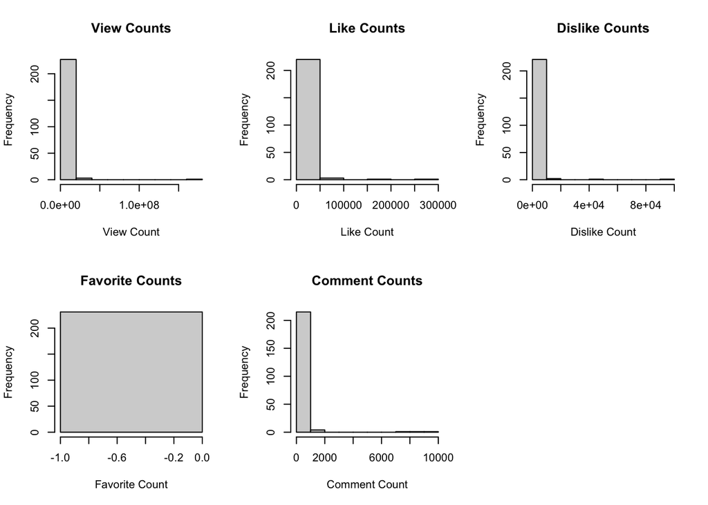

```r
#problem3_b
par(mfrow = c(2, 3))
hist(
  youtube_clean$view_count,
  main = "View Counts",
  xlab = "View Count"
)
hist(
  youtube_clean$like_count,
  main = "Like Counts",
  xlab = "Like Count"
)
hist(
  youtube_clean$dislike_count,
  main = "Dislike Counts",
  xlab = "Dislike Count"
)
hist(
  youtube_clean$favorite_count,
  main = "Favorite Counts",
  xlab = "Favorite Count"
)
hist(
  youtube_clean$comment_count,
  main = "Comment Counts",
  xlab = "Comment Count"
)
par(mfrow = c(1, 1))
```

```r
summary(youtube_clean$favorite_count)
```

```
   Min. 1st Qu.  Median    Mean 3rd Qu.    Max.     NAs
      0       0       0       0       0       0      16
```

```r
unique(youtube_clean$favorite_count)
```

```
[1]  0 NA
```

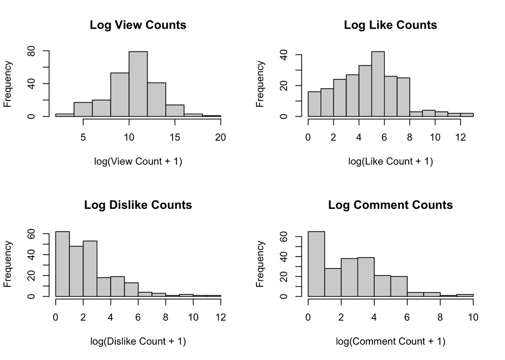

```r
youtube_clean$log_view_count <-
  log1p(youtube_clean$view_count)
youtube_clean$log_like_count <-
  log1p(youtube_clean$like_count)
youtube_clean$log_dislike_count <-
  log1p(youtube_clean$dislike_count)
youtube_clean$log_comment_count <-
  log1p(youtube_clean$comment_count)
par(mfrow = c(2, 2))
hist(
  youtube_clean$log_view_count,
  main = "Log View Counts",
  xlab = "log(View Count + 1)"
)
hist(
  youtube_clean$log_like_count,
  main = "Log Like Counts",
  xlab = "log(Like Count + 1)"
)
hist(
  youtube_clean$log_dislike_count,
  main = "Log Dislike Counts",
  xlab = "log(Dislike Count + 1)"
)
hist(
  youtube_clean$log_comment_count,
  main = "Log Comment Counts",
  xlab = "log(Comment Count + 1)"
)
```

```r
par(mfrow = c(1, 1))
```

### Explanation problem3(b)

The view counts, like counts, dislike counts, and comment counts are strongly right-skewed. Therefore, I use a log transformation, specifically log(x+1), to reduce the skewness and allow zero counts. The favorite_count variable is not appropriate as an outcome because it has no variation, with all observations having the same value. Thus, the four appropriate outcomes are log-transformed view counts, like counts, dislike counts, and comment counts.

```r
#problem3_c
characteristics <- c(
  "funny",
  "show_product_quickly",
  "patriotic",
  "celebrity",
  "danger",
  "animals",
  "use_sex"
)
outcomes <- c(
  "log_view_count",
  "log_like_count",
  "log_dislike_count",
  "log_comment_count"
)
youtube_clean[characteristics] <-
  lapply(
    youtube_clean[characteristics],
    as.numeric
  )
results <- list()
for (outcome in outcomes) {
  for (characteristic in characteristics) {
    formula <- as.formula(
      paste(
        outcome,
        "~",
        characteristic,
        "+ year"
      )
    )
    model <- lm(
      formula,
      data = youtube_clean
    )
    coefficient <-
      coef(summary(model))[
        characteristic,
        "Estimate"
      ]
    p_value <-
      coef(summary(model))[
        characteristic,
        "Pr(>|t|)"
      ]
    results[[length(results) + 1]] <-
      data.frame(
        outcome = outcome,
        characteristic = characteristic,
        estimate = coefficient,
        p_value = p_value
      )
  }
}
results <- do.call(
  rbind,
  results
)
results$significant <-
  results$p_value < 0.05
results
```

```
             outcome       characteristic    estimate    p_value significant
1     log_view_count                funny  0.52984356 0.20510610       FALSE
2     log_view_count show_product_quickly  0.20898031 0.60072225       FALSE
3     log_view_count            patriotic  0.13692497 0.78391866       FALSE
4     log_view_count            celebrity -0.01898556 0.96288885       FALSE
5     log_view_count               danger  0.66678076 0.09406479       FALSE
6     log_view_count              animals -0.17326980 0.64669142       FALSE
7     log_view_count              use_sex -0.29629543 0.49051595       FALSE
8     log_like_count                funny  0.36019066 0.34005646       FALSE
9     log_like_count show_product_quickly  0.16825538 0.64047730       FALSE
10    log_like_count            patriotic  0.49311233 0.28968290       FALSE
11    log_like_count            celebrity  0.26297830 0.47787826       FALSE
12    log_like_count               danger  0.62526219 0.08031647       FALSE
13    log_like_count              animals  0.02459257 0.94282914       FALSE
14    log_like_count              use_sex -0.32497453 0.40008928       FALSE
15 log_dislike_count                funny  0.04148774 0.89580597       FALSE
16 log_dislike_count show_product_quickly  0.24290875 0.42097425       FALSE
17 log_dislike_count            patriotic  0.66965405 0.08563747       FALSE
18 log_dislike_count            celebrity -0.28325315 0.36162721       FALSE
19 log_dislike_count               danger  0.18514931 0.53794989       FALSE
20 log_dislike_count              animals -0.07378053 0.79742453       FALSE
21 log_dislike_count              use_sex -0.38888066 0.22927926       FALSE
22 log_comment_count                funny  0.04746590 0.87934573       FALSE
23 log_comment_count show_product_quickly  0.34602814 0.24685774       FALSE
24 log_comment_count            patriotic  0.51478460 0.16854269       FALSE
25 log_comment_count            celebrity  0.22806291 0.45558834       FALSE
26 log_comment_count               danger  0.10642262 0.72095533       FALSE
27 log_comment_count              animals -0.19176266 0.49906680       FALSE
28 log_comment_count              use_sex -0.34939714 0.27353634       FALSE
```

```r
significant_results <-
  results[
    results$p_value < 0.05,
  ]
significant_results
```

```
[1] outcome        characteristic estimate       p_value        significant
<0 rows> (or 0-length row.names)
```

```r
view_results <-
  results[
    results$outcome == "log_view_count",
  ]
view_results
```

```
         outcome       characteristic    estimate    p_value significant
1 log_view_count                funny  0.52984356 0.20510610       FALSE
2 log_view_count show_product_quickly  0.20898031 0.60072225       FALSE
3 log_view_count            patriotic  0.13692497 0.78391866       FALSE
4 log_view_count            celebrity -0.01898556 0.96288885       FALSE
5 log_view_count               danger  0.66678076 0.09406479       FALSE
6 log_view_count              animals -0.17326980 0.64669142       FALSE
7 log_view_count              use_sex -0.29629543 0.49051595       FALSE
```

```r
best_characteristic <-
  view_results$characteristic[
    which.min(view_results$p_value)
  ]
best_characteristic
```

```
[1] "danger"
```

```r
view_results[
  which.min(view_results$p_value),
]
```

```
         outcome characteristic  estimate    p_value significant
5 log_view_count         danger 0.6667808 0.09406479       FALSE
```

### Explanation problem3(c)

I fitted 28 regression models, controlling for year in each model. At the 0.05 significance level, none of the commercial characteristics was statistically significant for the four outcomes. For log-transformed view counts, **danger** had the smallest p-value (p = 0.0941) and an estimated coefficient of 0.6668. The positive coefficient suggests a positive association with log view counts, but the association was not statistically significant.

```r
#problem3_d
# Remove observations with missing values
d <- youtube_clean[
  complete.cases(
    youtube_clean[
      ,
      c(
        "log_view_count",
        best_characteristic,
        "year"
      )
    ]
  ),
]
# Response vector
y <- d$log_view_count
# Design matrix
X <- cbind(
  1,
  d[[best_characteristic]],
  d$year
)
# OLS using matrix algebra
beta_hat <-
  solve(t(X) %*% X) %*%
  t(X) %*%
  y
# Display matrix algebra results
beta_hat
```

```
             [,1]
[1,] -31.39149243
[2,]   0.66678076
[3,]   0.02065641
```

```r
# Fit the same model using lm()
formula_d <- as.formula(
  paste(
    "log_view_count ~",
    best_characteristic,
    "+ year"
  )
)
model_d <- lm(
  formula_d,
  data = d
)
beta_lm <- coef(model_d)
# Display lm results
beta_lm
```

```
 (Intercept)       danger         year
-31.39149243   0.66678076   0.02065641
```

```r
# Compare results
comparison <- cbind(
  matrix_algebra = as.vector(beta_hat),
  lm = as.numeric(beta_lm)
)
comparison
```

```
     matrix_algebra           lm
[1,]   -31.39149243 -31.39149243
[2,]     0.66678076   0.66678076
[3,]     0.02065641   0.02065641
```

```r
# Check whether they are equal
all.equal(
  as.vector(beta_hat),
  as.numeric(beta_lm),
  tolerance = 1e-10)
```

```
[1] TRUE
```

### Explanation problem3(d)

I used danger, which had the smallest p-value for predicting log-transformed view counts in Part (c). The design matrix included an intercept, danger, and year. Using the OLS matrix formula β^=(XTX)−1XTy,\hat{\beta}=(X^TX)^{-1}X^Ty, I obtained the coefficient estimates: β^0=−31.3915,β^1=0.6668,β^2=0.02066.\hat{\beta}_0=-31.3915,\qquad \hat{\beta}_1=0.6668,\qquad \hat{\beta}_2=0.02066. Therefore, the fitted model is log(view count+1)^=−31.3915+0.6668(danger)+0.02066(year).\widehat{\log(\text{view count}+1)} = -31.3915+0.6668(\text{danger})+0.02066(\text{year}). The coefficients obtained using matrix algebra were exactly the same as those obtained using lm(). The all.equal() result was TRUE, confirming that the matrix formula produces the same OLS estimates as lm().

Holding year constant, commercials with the danger characteristic have an estimated 0.6668 higher log-transformed view count than commercials without this characteristic. Holding danger constant, a one-year increase in year is associated with an estimated 0.02066 increase in log-transformed view count.